# act_report

## Report: act_report

### Introduction

WeRateDogs is a Twitter account that rates people's dogs with a humorous comment about the dog. These ratings almost always have a denominator of 10. The numerators, though? Almost always greater than 10. 11/10, 12/10, 13/10, etc. Why? Because "they're good dogs Brent." WeRateDogs has over 4 million followers and has received international media coverage

## Analyzing and Visualizing Data

```python
import pandas as pd
import matplotlib.pyplot as plt
```

```python
# Loading the twitter_archive_master as a dataframe
twt_arch_ms = pd.read_csv('twitter_archive_master.csv')
```

### Question 1: What are the top 5 most common dog breed

```python
# The code to get this
breed_count = twt_arch_ms['dog_breed'].value_counts()[:5]

# Print the list of top 5 dog_breed
breed_count
```

```
golden retriever      24
Labrador retriever    15
Chihuahua             13
pug                   12
toy poodle            10
Name: dog_breed, dtype: int64
```

Above is the list of the **Top 5 Dog Breeds**

### Question 2: What is the relationship between favourite count and retweet count

This relationship would be explored with the help of a scatter plot

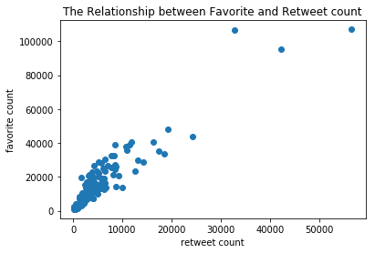

```python
# The code to plot this
plt.scatter(twt_arch_ms['retweet_count'], twt_arch_ms['favorite_count']);
plt.title('The Relationship between Favorite and Retweet count')
plt.xlabel('retweet count')
plt.ylabel('favorite count')
plt.show();
```

There seems to be a correlation between favourite and retweet count

Basically, the more the retweet , the more the favorite count

### Question 3: Informatiom about the highest rating in the dataset

```python
# Get the maximum rating
max_rating = twt_arch_ms.rating_numerator.max()
```

```python
# A view of some info about the maximum rating in the dataset
twt_arch_ms[twt_arch_ms['rating_numerator'] == max_rating][['dog_breed', 'dog_stage', 'rating_numerator']]
```

|  | dog_breed | dog_stage | rating_numerator |
| --- | --- | --- | --- |
| 164 | Siberian husky | pupper | 50 |

### Question 4: What dog stages have the most favorite count

```python
# Group the data by dog stage
stage = twt_arch_ms.groupby('dog_stage')
```

```python
# Function to plot the graph
def plot_avg_fav(df):
    fav_avg = []
    stages = []
    for i in twt_arch_ms['dog_stage'].unique():
        fav_avg.append(stage.get_group(i)['favorite_count'].mean())
        stages.append(i)

    plt.bar(stages, fav_avg);

    plt.title('Average Favorite Count per dog stage')
    plt.xlabel('Dog stage')
    plt.ylabel('Average Favorite Count')

    return plt.show()
```

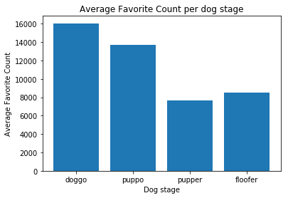

```python
# Code to call the function
plot_avg_fav(stage)
```

I think I speak for everyone when I say that the graph speaks for itself